# Introduction

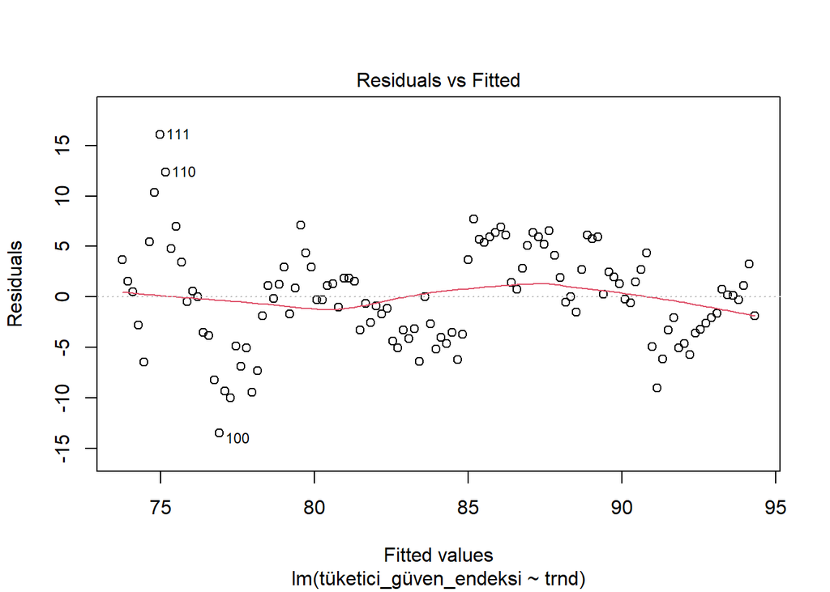

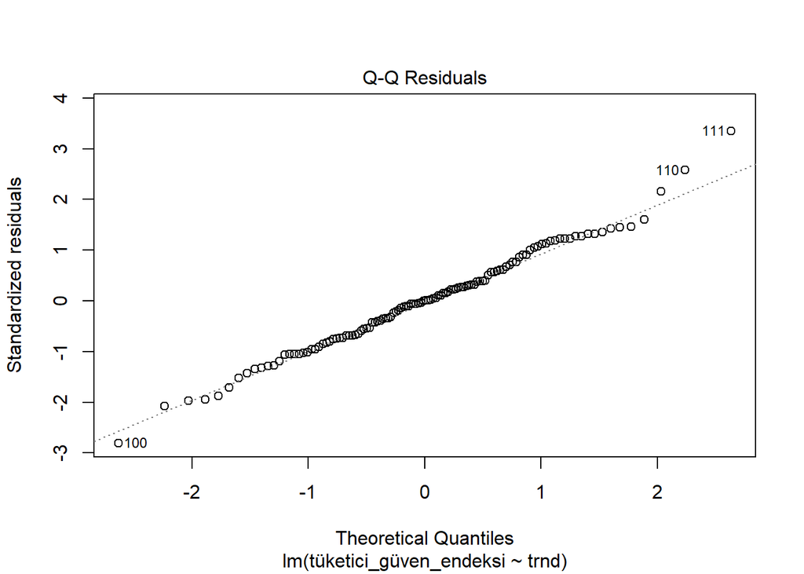

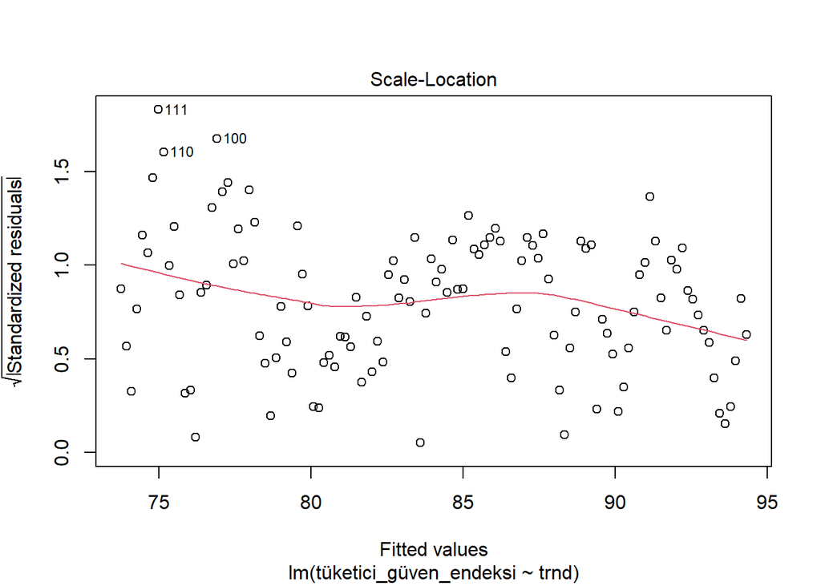

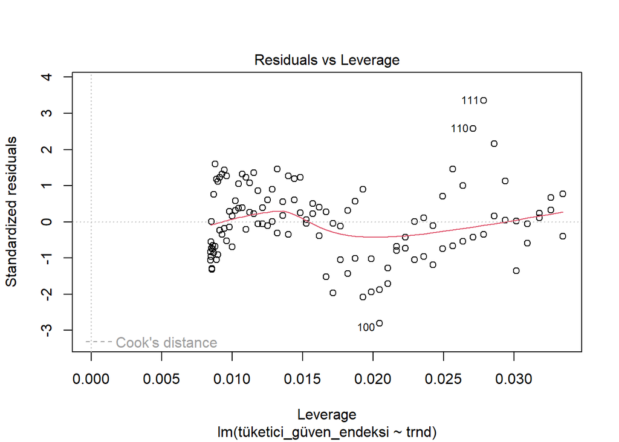

```r
plot(lm_base1)
```

Let’s add independent variables to our model. Those changes will increase our R-squared value, a better residual-fitted distribution. This means our residuals lay around 0.

```r
lm_base1=lm(tüketici_güven_endeksi~trnd+ticari_faiz,data)
summary(lm_base1)
```

```
##
## Call:
## lm(formula = tüketici_güven_endeksi ~ trnd + ticari_faiz, data = data)
##
## Residuals:
##      Min       1Q   Median       3Q      Max
## -13.1486  -3.2690  -0.2381   3.3516  14.7827
##
## Coefficients:
##             Estimate Std. Error t value Pr(>|t|)
## (Intercept) 96.26387    1.20712  79.747   <2e-16 ***
## trnd        -0.16033    0.01476 -10.862   <2e-16 ***
## ticari_faiz -0.14253    0.06593  -2.162   0.0327 *
## ---
## Signif. codes:  0 '***' 0.001 '**' 0.01 '*' 0.05 '.' 0.1 ' ' 1
##
## Residual standard error: 4.785 on 115 degrees of freedom
## Multiple R-squared:  0.6221, Adjusted R-squared:  0.6155
## F-statistic: 94.66 on 2 and 115 DF,  p-value: < 2.2e-16
```

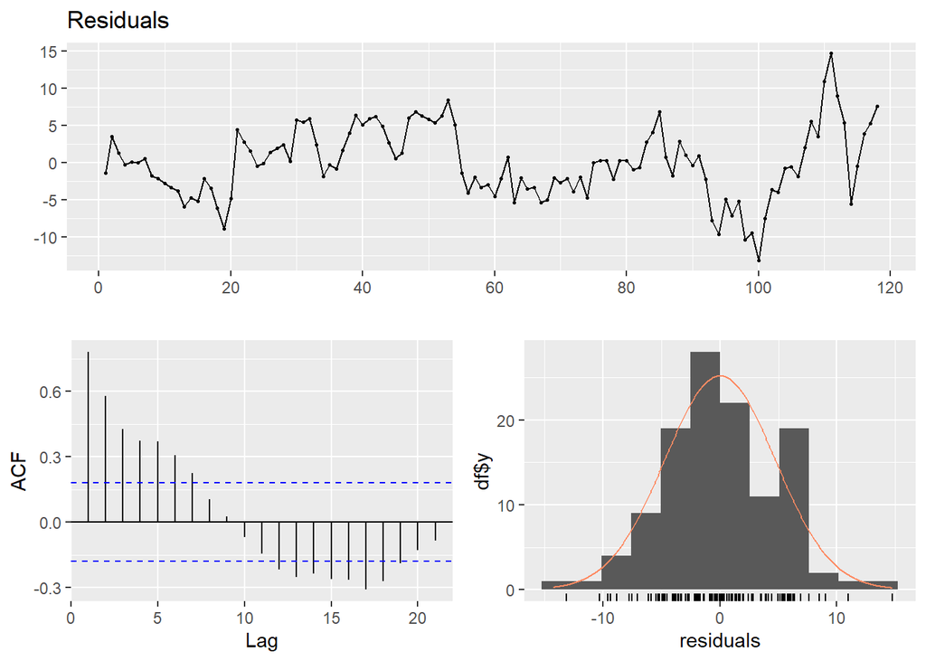

```
##
##  Ljung-Box test
##
## data:  Residuals
## Q* = 191.66, df = 10, p-value < 2.2e-16
##
## Model df: 0.   Total lags used: 10
```

```r
checkresiduals(lm_base1$residuals)
```

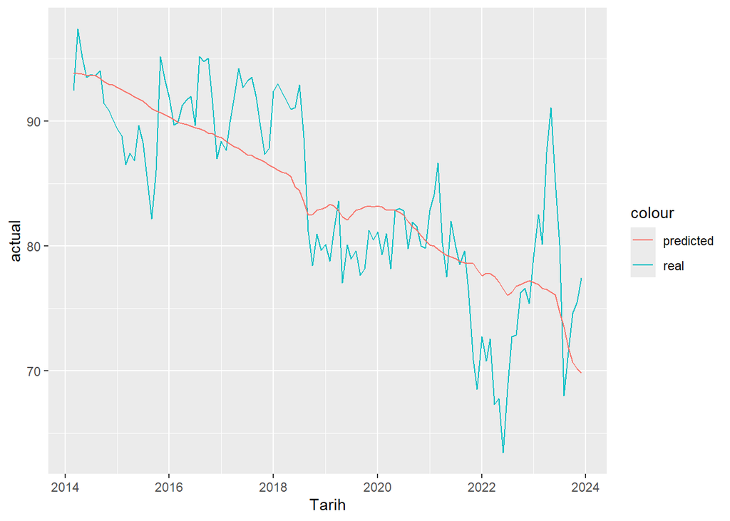

```r
tmp1=copy(data)
tmp1[,actual:=tüketici_güven_endeksi]
tmp1[,predicted_trend_ticari_faiz:=predict(lm_base1,tmp)]
tmp1[,residual_trend_ticari_faiz:=actual-predicted_trend_ticari_faiz]
#head(tmp)
ggplot(tmp1 ,aes(x=Tarih)) +
        geom_line(aes(y=actual,color='real')) +
        geom_line(aes(y=predicted_trend_ticari_faiz,color='predicted'))
```

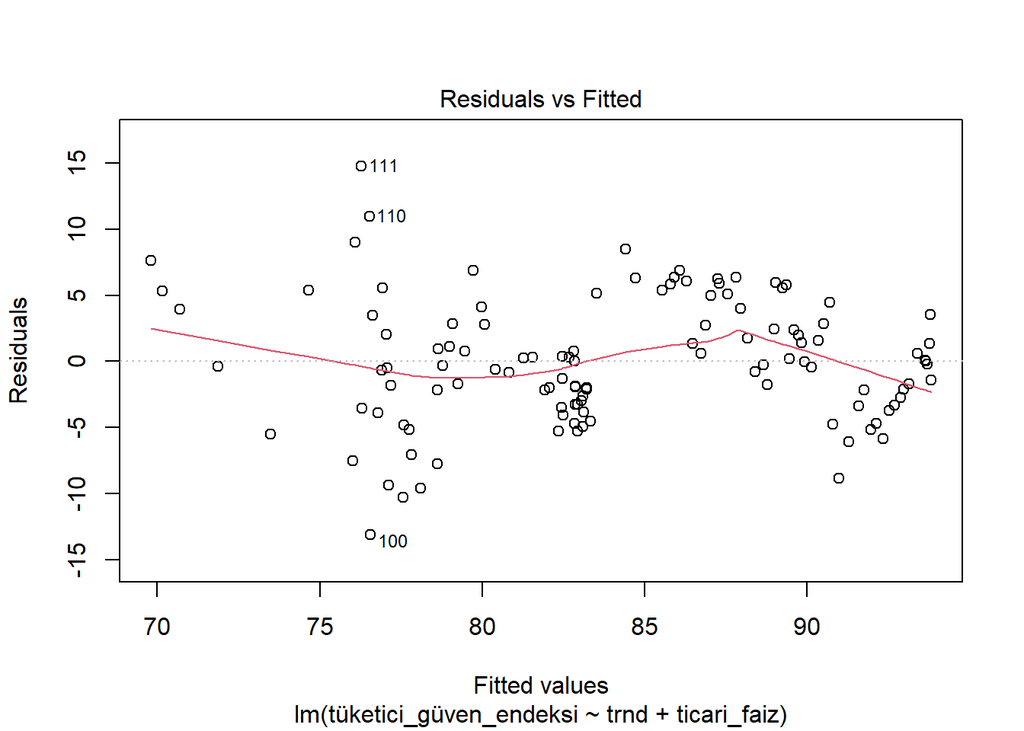

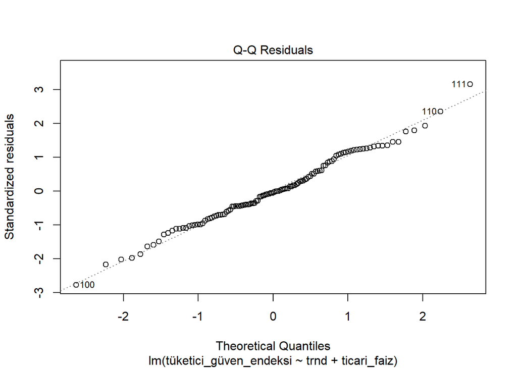

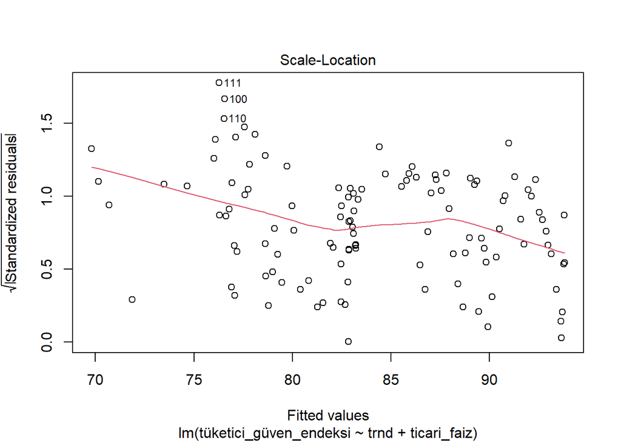

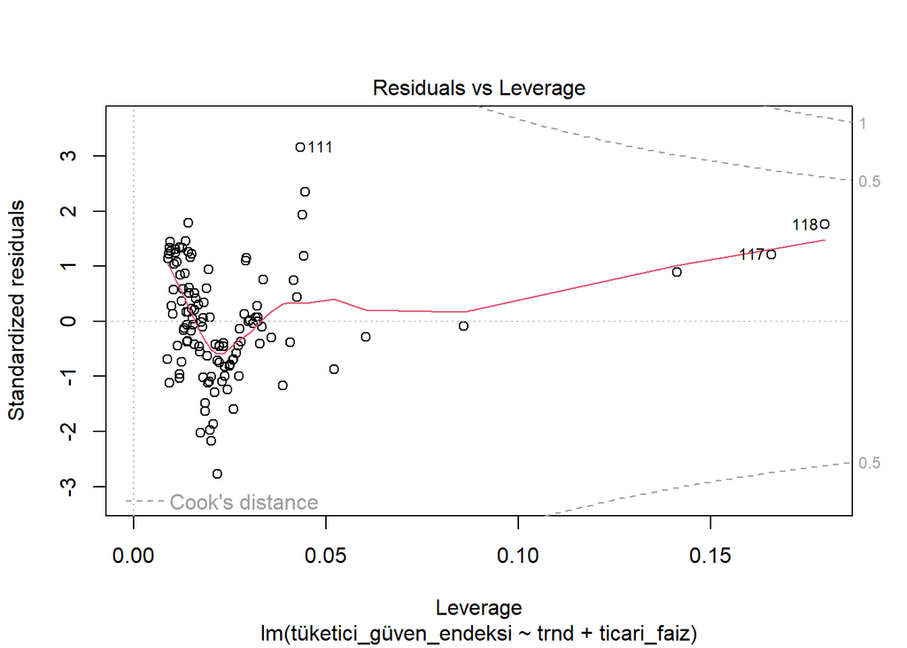

```r
plot(lm_base1)
```

```r
lm_base1=lm(tüketici_güven_endeksi~trnd+ticari_faiz+reel_güven_indeksi,data)
summary(lm_base1)
```

```
##
## Call:
## lm(formula = tüketici_güven_endeksi ~ trnd + ticari_faiz +
##     reel_güven_indeksi, data = data)
##
## Residuals:
##     Min      1Q  Median      3Q     Max
## -13.601  -2.566  -0.348   3.189  14.190
##
## Coefficients:
##                    Estimate Std. Error t value Pr(>|t|)
## (Intercept)        78.88622    6.73355  11.715  < 2e-16 ***
## trnd               -0.16084    0.01440 -11.170  < 2e-16 ***
## ticari_faiz        -0.12659    0.06459  -1.960  0.05246 .
## reel_güven_indeksi  0.16420    0.06264   2.621  0.00996 **
## ---
## Signif. codes:  0 '***' 0.001 '**' 0.01 '*' 0.05 '.' 0.1 ' ' 1
##
## Residual standard error: 4.667 on 114 degrees of freedom
## Multiple R-squared:  0.6436, Adjusted R-squared:  0.6342
## F-statistic: 68.62 on 3 and 114 DF,  p-value: < 2.2e-16
```

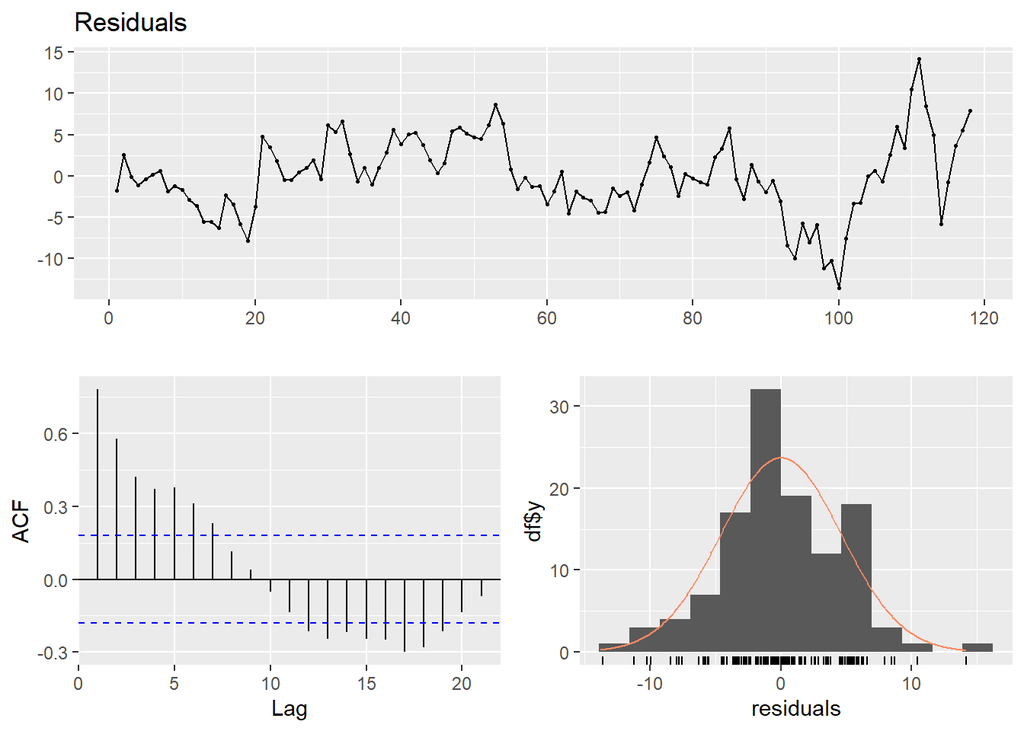

```
##
##  Ljung-Box test
##
## data:  Residuals
## Q* = 192.22, df = 10, p-value < 2.2e-16
##
## Model df: 0.   Total lags used: 10
```

```r
checkresiduals(lm_base1$residuals)
```

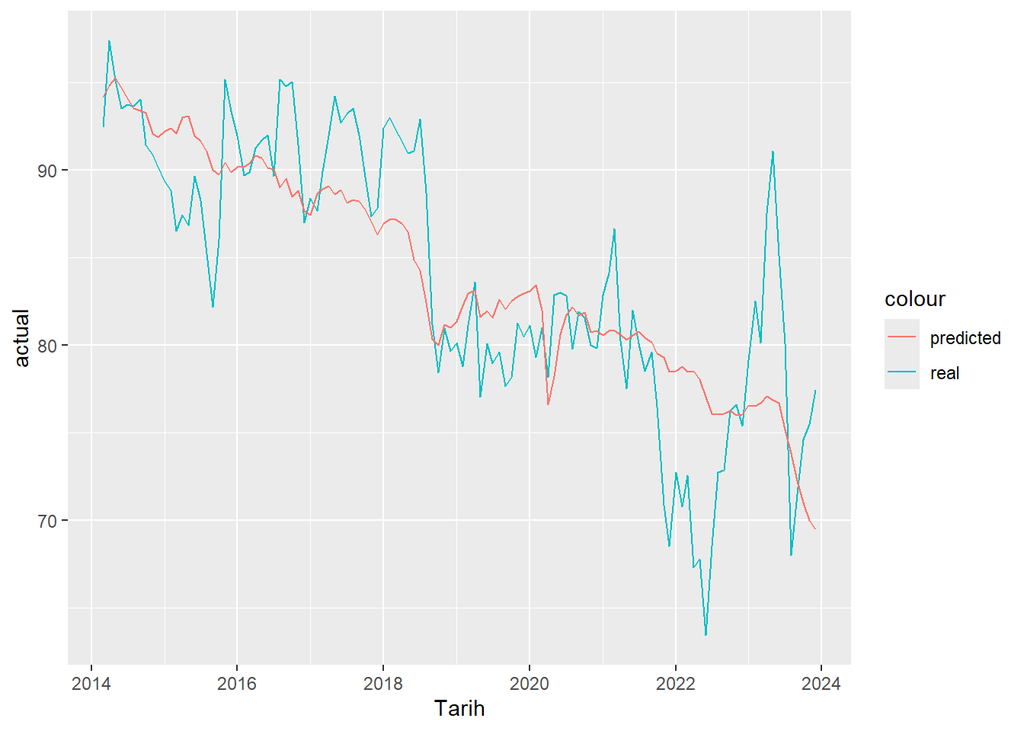

```r
tmp1=copy(data)
tmp1[,actual:=tüketici_güven_endeksi]
tmp1[,predicted_trend_ticari_faiz_reel_güven:=predict(lm_base1,tmp)]
tmp1[,residual_trend_ticari_faiz_reel_güven:=actual-predicted_trend_ticari_faiz_reel_güven]
#head(tmp)
ggplot(tmp1 ,aes(x=Tarih)) +
        geom_line(aes(y=actual,color='real')) +
        geom_line(aes(y=predicted_trend_ticari_faiz_reel_güven,color='predicted'))
```

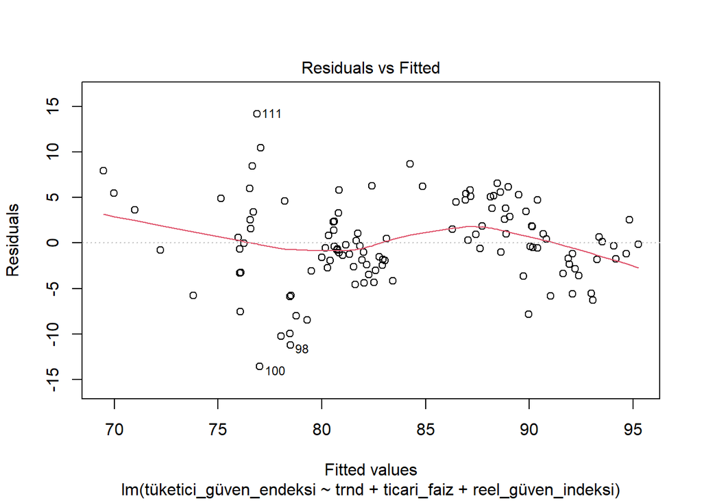

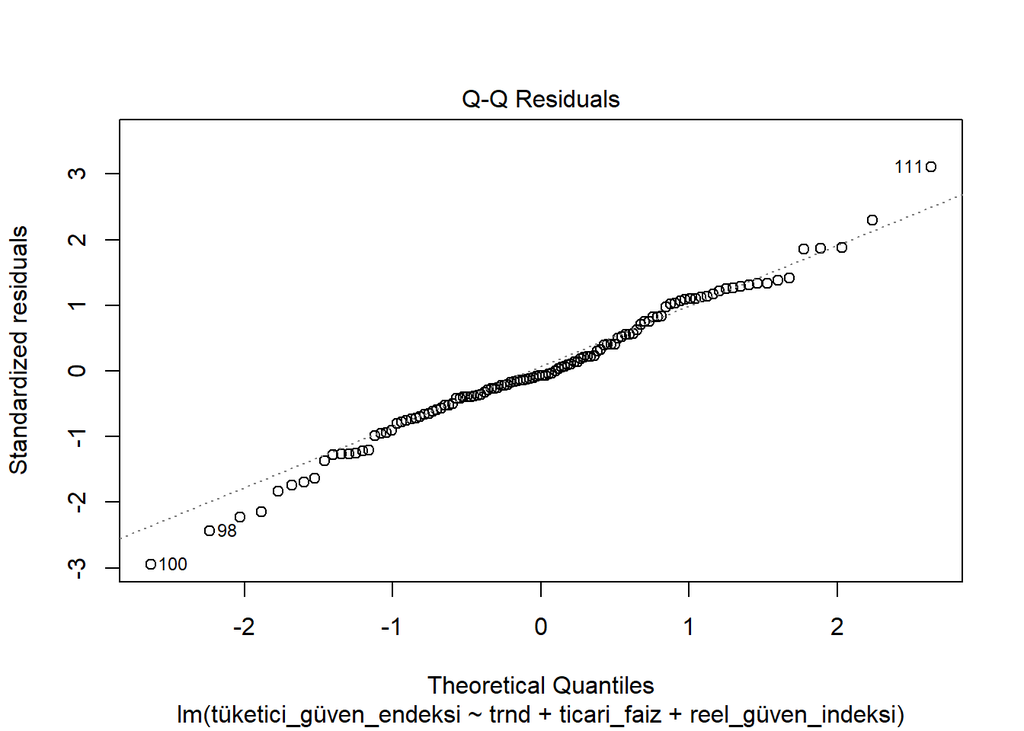

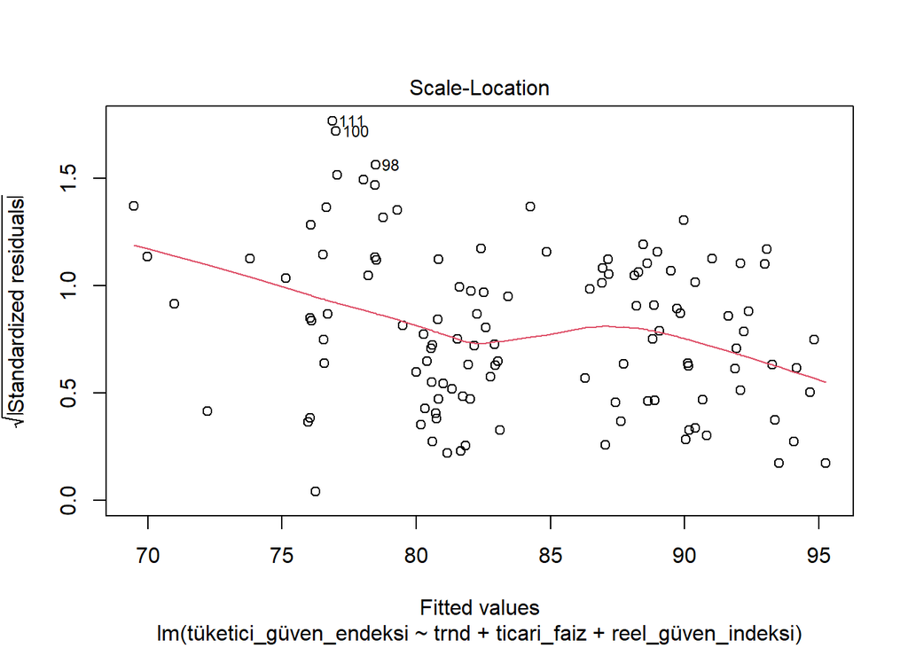

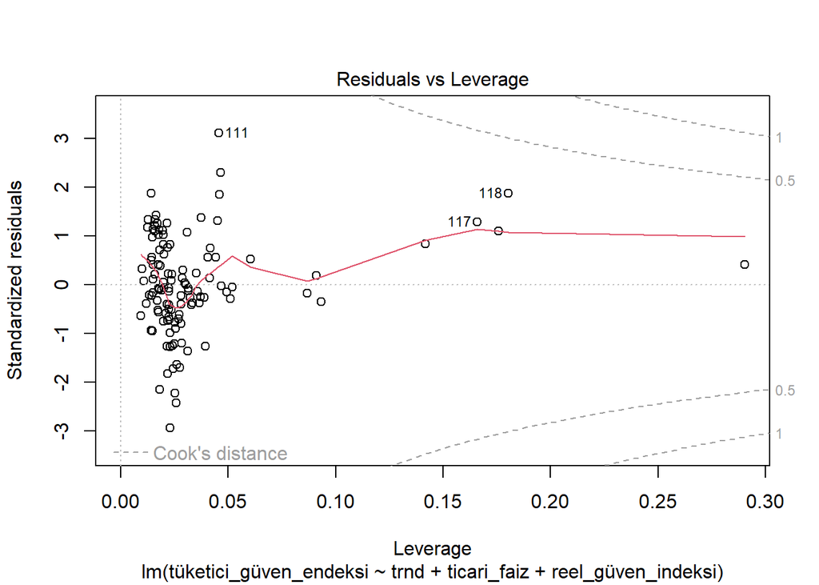

```r
plot(lm_base1)
```

## Model 3

Last but not least, we will be looking at the “Total Number of Closed Businesses,” meaning that we will examine the factors influencing the closure of businesses over time and analyze trends to identify potential economic or sector-specific challenges.

Let’s look at the visualization and data, as always.

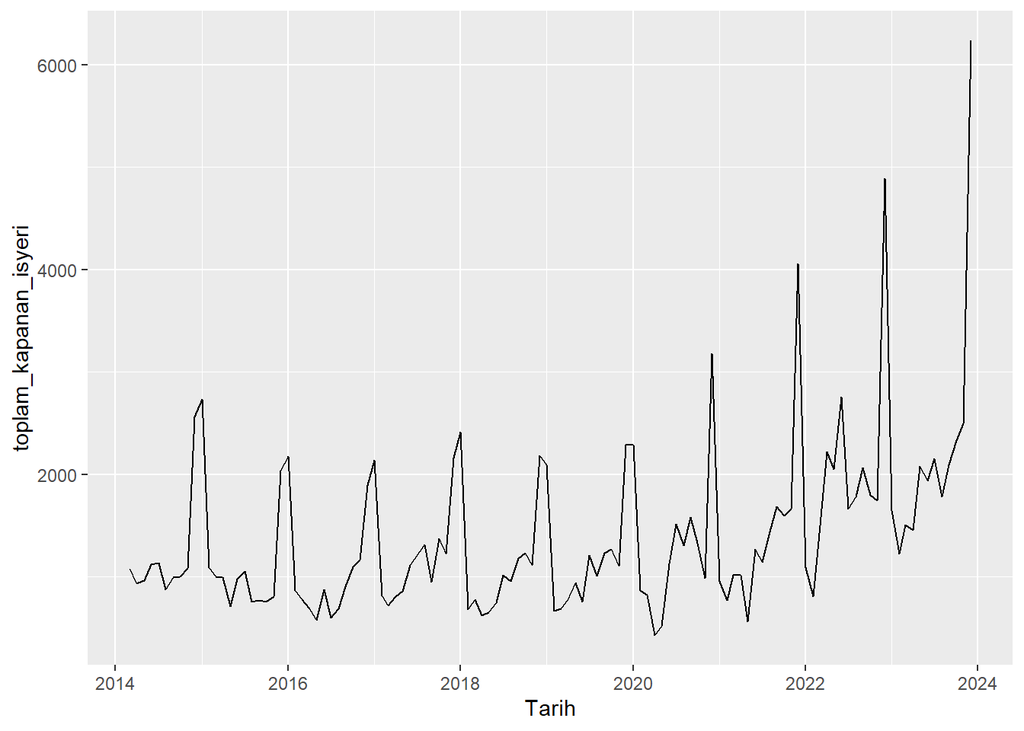

```r
ggplot(data ,aes(x=Tarih,y=toplam_kapanan_isyeri, group=1)) + geom_line()
```

It is logical to use “Financial Confidence Index” and “Total Number of Offices” data. Those will be helpful for us to analyze our independent data.

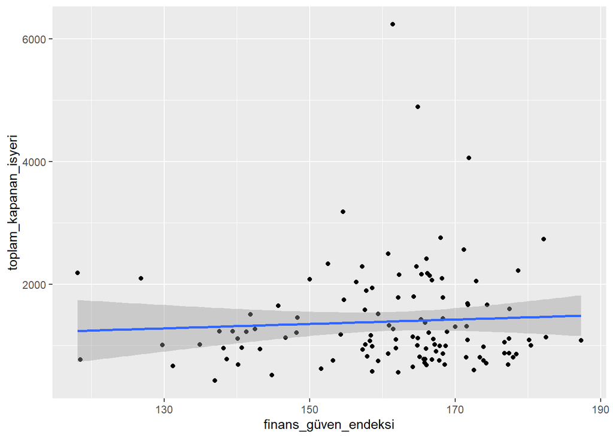

```r
ggplot(data ,aes(x=finans_güven_endeksi,y=toplam_kapanan_isyeri)) + geom_point() +geom_smooth(method='lm')
```

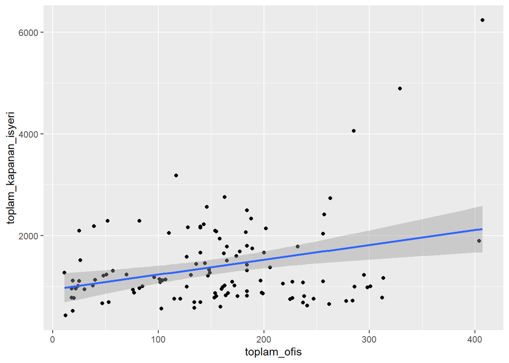

```r
ggplot(data ,aes(x=toplam_ofis,y=toplam_kapanan_isyeri)) + geom_point() +geom_smooth(method='lm')
```

By plotting the commercial “Financial Confidence Index” and “Total Number of Offices”, let’s see if there is a monthly correlation.

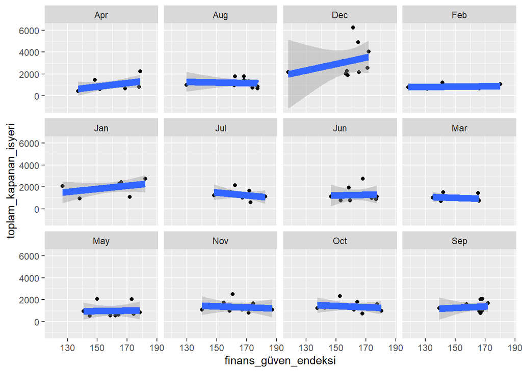

```r
ggplot(data,aes(x=finans_güven_endeksi,y=toplam_kapanan_isyeri)) +
        geom_point() + geom_smooth(method=lm,linewidth=3) + facet_wrap(~mon)
```

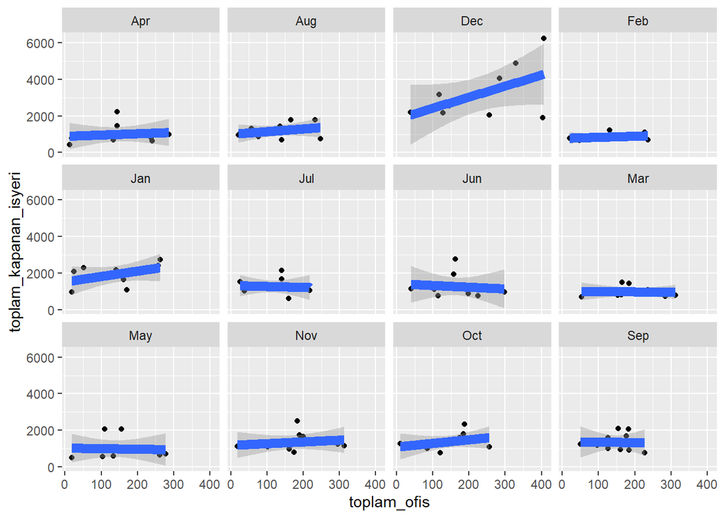

```r
ggplot(data,aes(x=toplam_ofis,y=toplam_kapanan_isyeri)) +
        geom_point() + geom_smooth(method=lm,linewidth=3) + facet_wrap(~mon)
```

Utilise Auto Correlation Function to see if there is any correlation within our data.

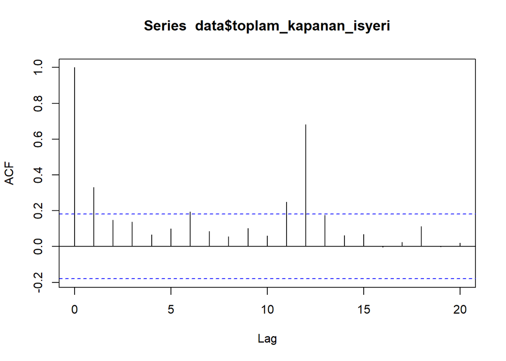

```r
acf(data$toplam_kapanan_isyeri)
```

```r
lm_base2=lm(toplam_kapanan_isyeri~trnd,data)
summary(lm_base2)
```

```
##
## Call:
## lm(formula = toplam_kapanan_isyeri ~ trnd, data = data)
##
## Residuals:
##     Min      1Q  Median      3Q     Max
## -1115.4  -428.8  -166.3   148.6  4243.5
##
## Coefficients:
##             Estimate Std. Error t value Pr(>|t|)
## (Intercept)  785.589    142.496   5.513 2.16e-07 ***
## trnd          10.228      2.078   4.921 2.87e-06 ***
## ---
## Signif. codes:  0 '***' 0.001 '**' 0.01 '*' 0.05 '.' 0.1 ' ' 1
##
## Residual standard error: 769 on 116 degrees of freedom
## Multiple R-squared:  0.1727, Adjusted R-squared:  0.1656
## F-statistic: 24.22 on 1 and 116 DF,  p-value: 2.873e-06
```

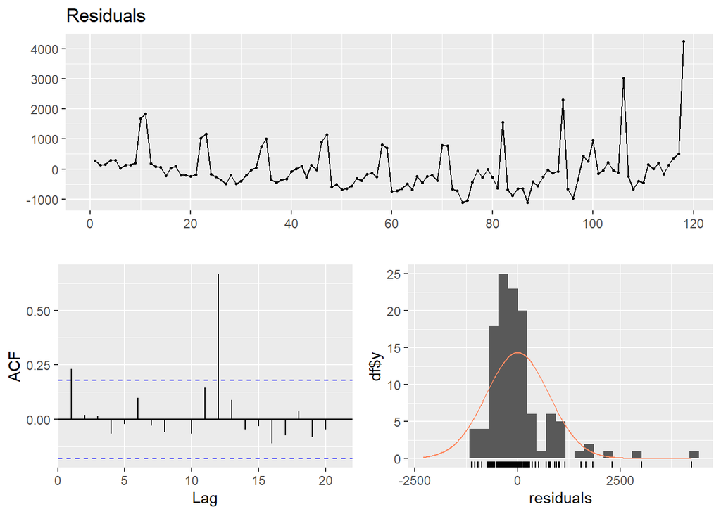

```
##
##  Ljung-Box test
##
## data:  Residuals
## Q* = 9.5599, df = 10, p-value = 0.4799
##
## Model df: 0.   Total lags used: 10
```

```r
checkresiduals(lm_base2$residuals)
```

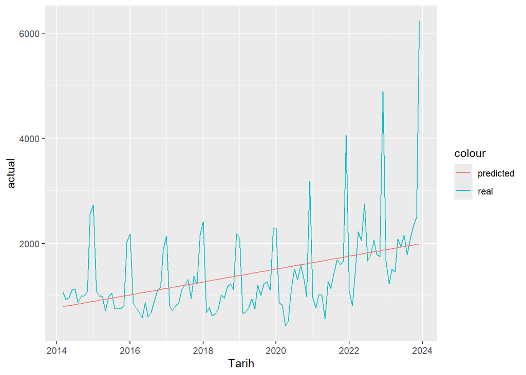

```r
tmp2=copy(data)
tmp2[,actual:=toplam_kapanan_isyeri]
tmp2[,predicted_trend:=predict(lm_base2,tmp)]
tmp2[,residual_trend:=actual-predicted_trend]
#head(tmp)
ggplot(tmp2 ,aes(x=Tarih)) +
        geom_line(aes(y=actual,color='real')) +
        geom_line(aes(y=predicted_trend,color='predicted'))
```

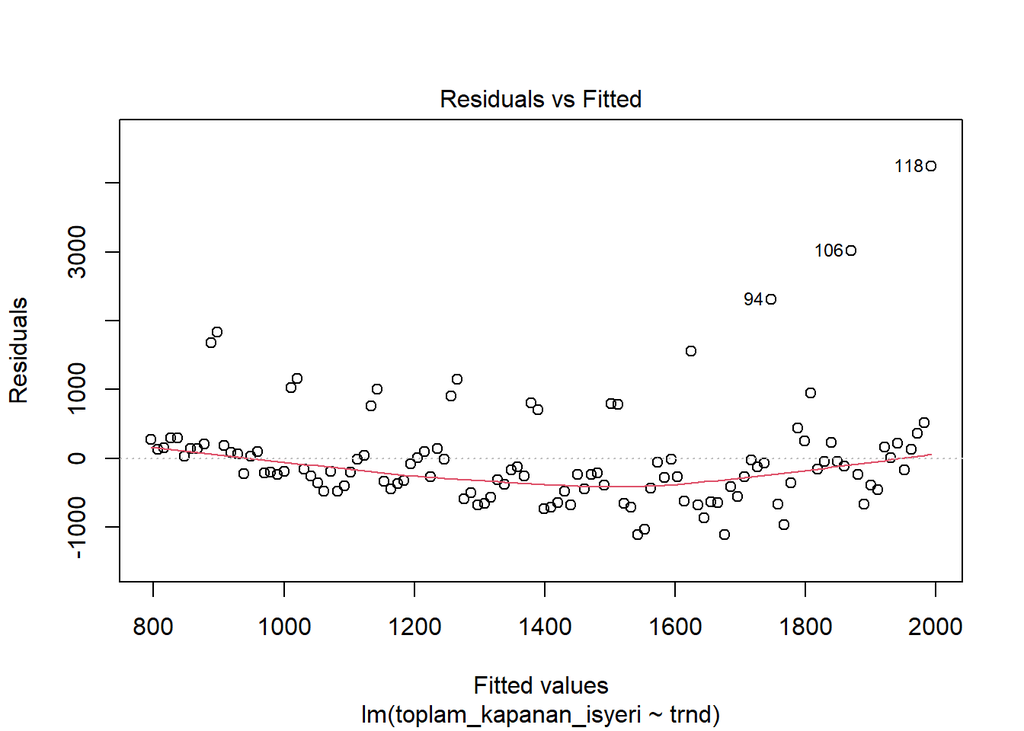

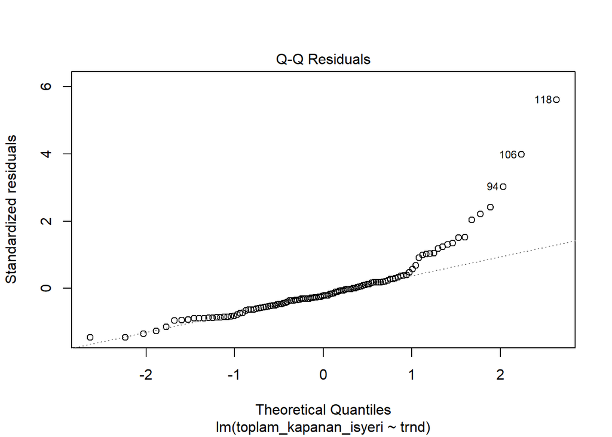

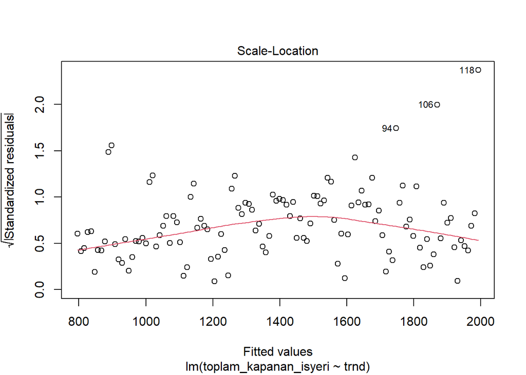

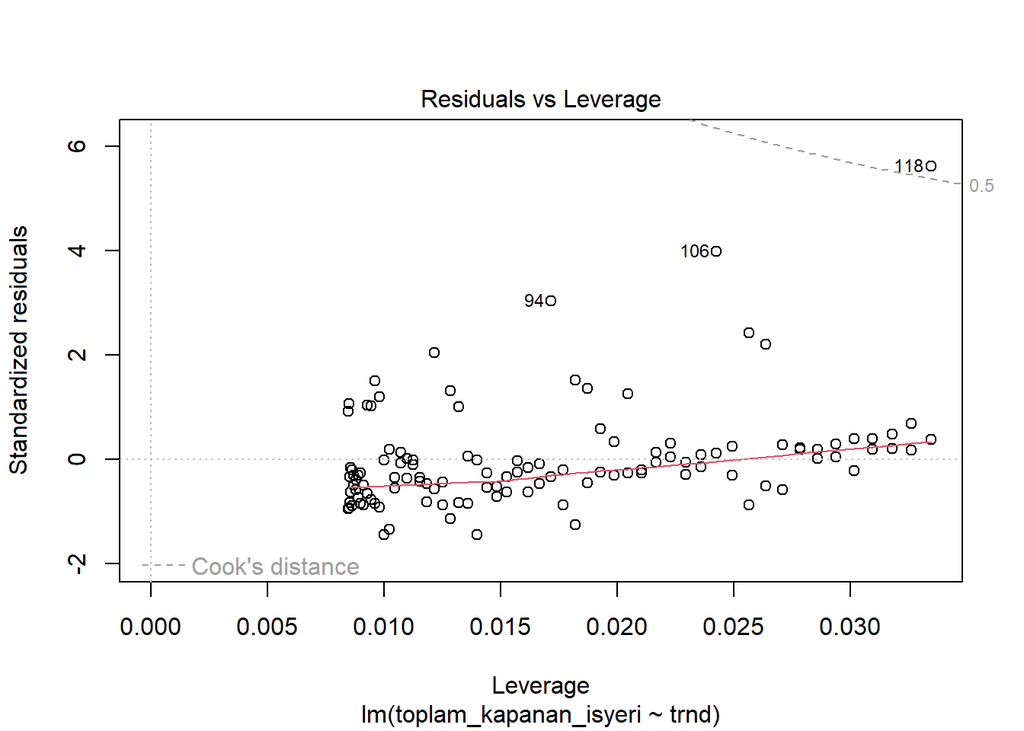

```r
plot(lm_base2)
```

Now, let’s add “Financial Confidence Index” data to the model for improvement.

```r
lm_base2=lm(toplam_kapanan_isyeri~trnd+finans_güven_endeksi,data)
summary(lm_base2)
```

```
##
## Call:
## lm(formula = toplam_kapanan_isyeri ~ trnd + finans_güven_endeksi,
##     data = data)
##
## Residuals:
##     Min      1Q  Median      3Q     Max
## -1165.2  -402.3  -196.4   109.6  4157.0
##
## Coefficients:
##                       Estimate Std. Error t value Pr(>|t|)
## (Intercept)          -1223.274    900.582  -1.358   0.1770
## trnd                    11.626      2.134   5.447 2.95e-07 ***
## finans_güven_endeksi    11.961      5.297   2.258   0.0258 *
## ---
## Signif. codes:  0 '***' 0.001 '**' 0.01 '*' 0.05 '.' 0.1 ' ' 1
##
## Residual standard error: 755.8 on 115 degrees of freedom
## Multiple R-squared:  0.2078, Adjusted R-squared:  0.194
## F-statistic: 15.09 on 2 and 115 DF,  p-value: 1.521e-06
```

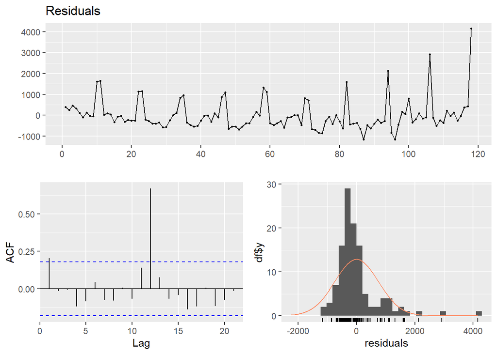

```
##
##  Ljung-Box test
##
## data:  Residuals
## Q* = 10.075, df = 10, p-value = 0.4339
##
## Model df: 0.   Total lags used: 10
```

```r
checkresiduals(lm_base2$residuals)
```

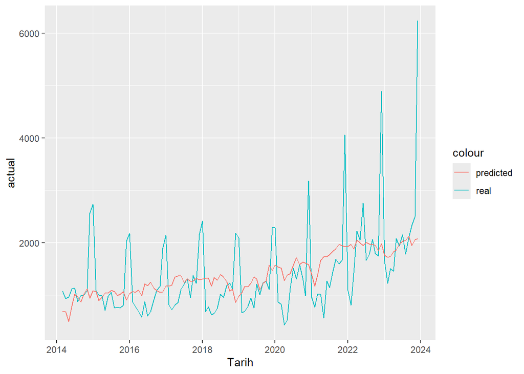

```r
tmp2=copy(data)
tmp2[,actual:=toplam_kapanan_isyeri]
tmp2[,predicted_trend_finans_güven_endeksi:=predict(lm_base2,tmp)]
tmp2[,residual_trend_finans_güven_endeksi:=actual-predicted_trend_finans_güven_endeksi]
#head(tmp)
ggplot(tmp2 ,aes(x=Tarih)) +
        geom_line(aes(y=actual,color='real')) +
        geom_line(aes(y=predicted_trend_finans_güven_endeksi,color='predicted'))
```

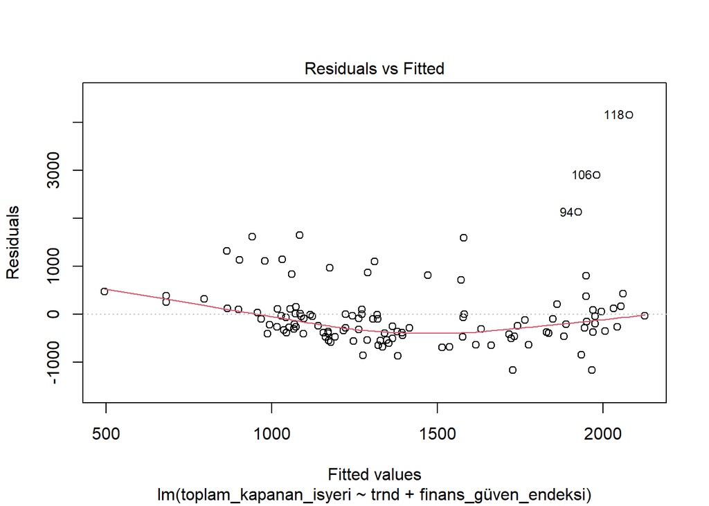

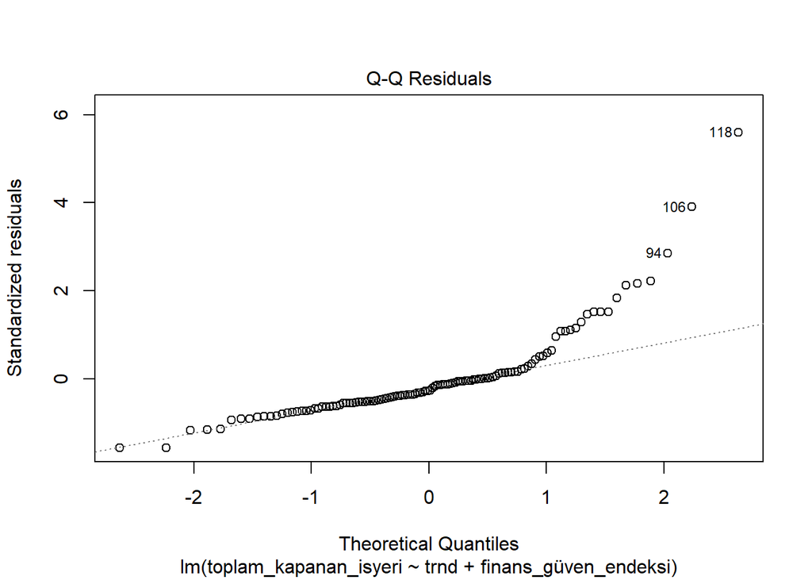

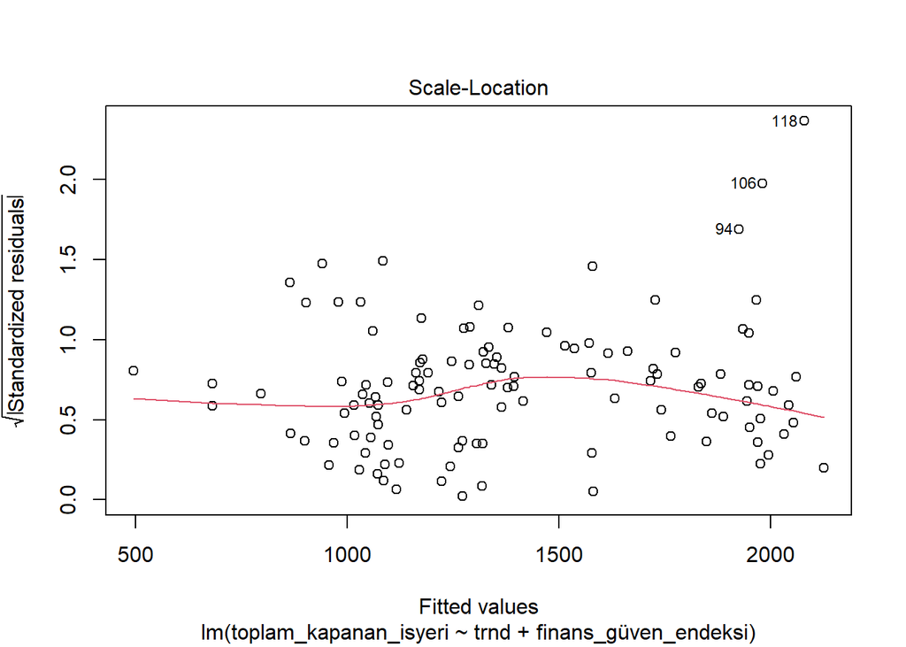

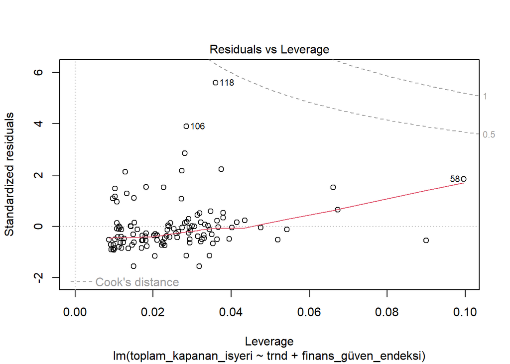

```r
plot(lm_base2)
```

Now it is time to add “Total Number of Offices” to the model for improvement.

```r
lm_base2=lm(toplam_kapanan_isyeri~trnd+finans_güven_endeksi+toplam_ofis,data)
summary(lm_base2)
```

```
##
## Call:
## lm(formula = toplam_kapanan_isyeri ~ trnd + finans_güven_endeksi +
##     toplam_ofis, data = data)
##
## Residuals:
##     Min      1Q  Median      3Q     Max
## -1033.4  -418.5  -176.2   234.1  3334.5
##
## Coefficients:
##                      Estimate Std. Error t value Pr(>|t|)
## (Intercept)          -142.543    897.231  -0.159 0.874052
## trnd                   11.492      2.018   5.693 9.84e-08 ***
## finans_güven_endeksi    2.107      5.633   0.374 0.709013
## toplam_ofis             3.312      0.866   3.824 0.000215 ***
## ---
## Signif. codes:  0 '***' 0.001 '**' 0.01 '*' 0.05 '.' 0.1 ' ' 1
##
## Residual standard error: 714.7 on 114 degrees of freedom
## Multiple R-squared:  0.2979, Adjusted R-squared:  0.2794
## F-statistic: 16.12 on 3 and 114 DF,  p-value: 8.396e-09
```

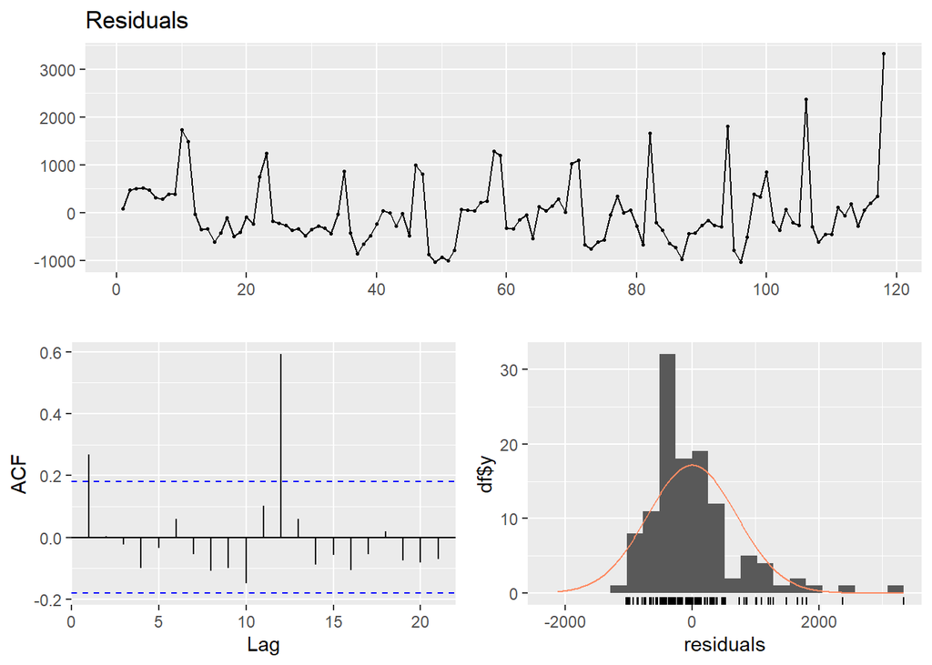

```
##
##  Ljung-Box test
##
## data:  Residuals
## Q* = 16.536, df = 10, p-value = 0.08529
##
## Model df: 0.   Total lags used: 10
```

```r
checkresiduals(lm_base2$residuals)
```

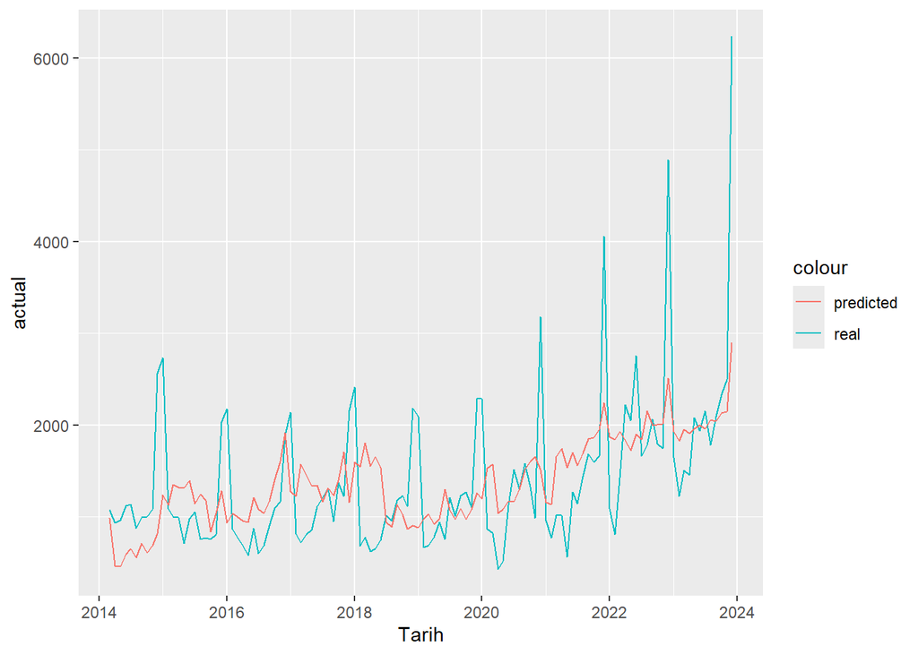

```r
tmp2=copy(data)
tmp2[,actual:=toplam_kapanan_isyeri]
tmp2[,predicted_trend_finans_güven_endeksi_toplam_ofis:=predict(lm_base2,tmp)]
tmp2[,residual_trend_finans_güven_endeksi_toplam_ofis:=actual-predicted_trend_finans_güven_endeksi_toplam_ofis]
#head(tmp)
ggplot(tmp2 ,aes(x=Tarih)) +
        geom_line(aes(y=actual,color='real')) +
        geom_line(aes(y=predicted_trend_finans_güven_endeksi_toplam_ofis,color='predicted'))
```

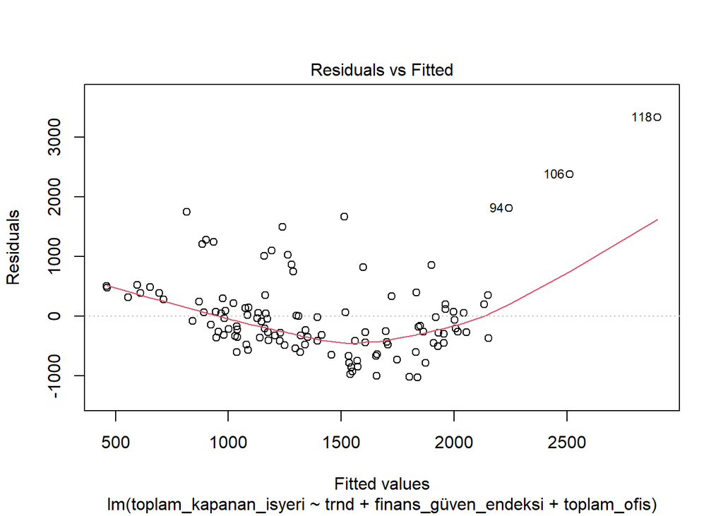

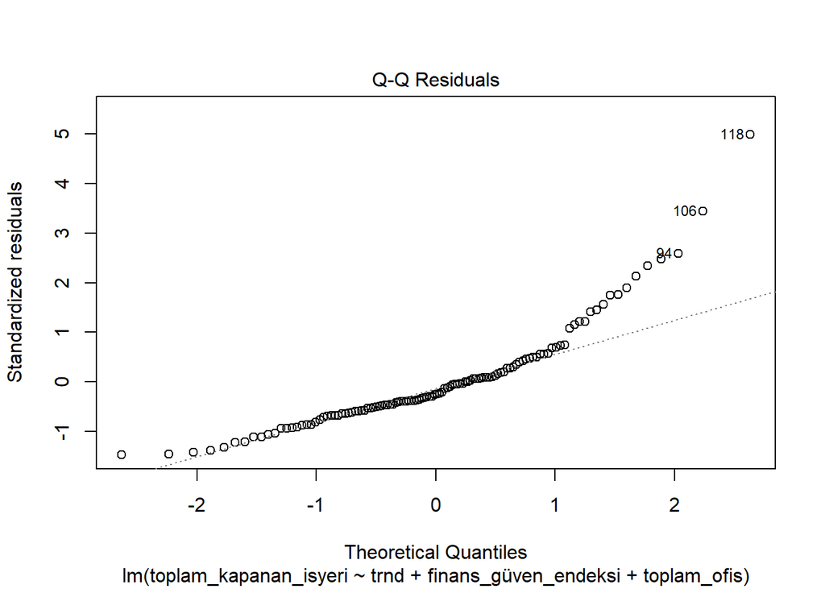

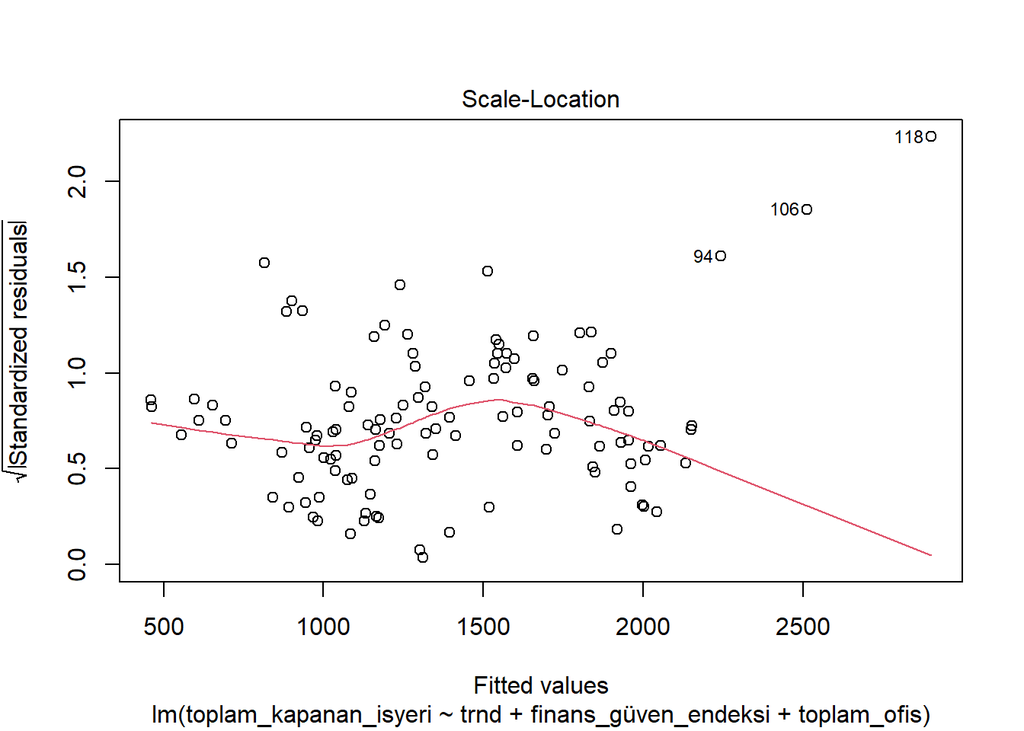

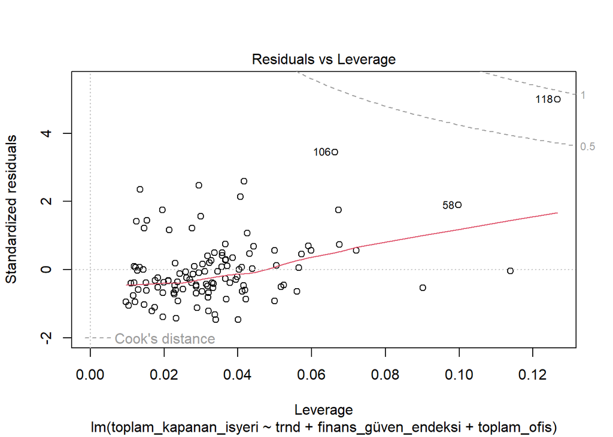

```r
plot(lm_base2)
```

Now we could check the year effect to see the relation. As observed in the bottom this improves our model, but we still have a very week model with a very low r-squared value. The exponential growth of the number of closed businesses could be interpreted with the use of logarithm function. This would take out the exp. effect and we would have a smoother graph.

```r
lm_base2=lm(toplam_kapanan_isyeri~trnd+finans_güven_endeksi+toplam_ofis+yıl,data)
summary(lm_base2)
```

```
##
## Call:
## lm(formula = toplam_kapanan_isyeri ~ trnd + finans_güven_endeksi +
##     toplam_ofis + yıl, data = data)
##
## Residuals:
##    Min     1Q Median     3Q    Max
## -968.0 -382.7 -158.0  113.8 2671.3
##
## Coefficients:
##                        Estimate Std. Error t value Pr(>|t|)
## (Intercept)            566.6786  1023.2588   0.554 0.580895
## trnd                    76.5344    18.3808   4.164 6.43e-05 ***
## finans_güven_endeksi    -1.5947     6.1100  -0.261 0.794606
## toplam_ofis              3.9934     0.9842   4.057 9.56e-05 ***
## yıl2015              -1378.4311   365.2549  -3.774 0.000266 ***
## yıl2016              -2247.1850   514.2259  -4.370 2.93e-05 ***
## yıl2017              -2977.5105   702.7414  -4.237 4.88e-05 ***
## yıl2018              -3810.8380   923.3198  -4.127 7.37e-05 ***
## yıl2019              -4280.1479  1155.5134  -3.704 0.000340 ***
## yıl2020              -5201.9865  1349.2683  -3.855 0.000199 ***
## yıl2021              -6220.4219  1559.4593  -3.989 0.000123 ***
## yıl2022              -6690.8164  1765.8635  -3.789 0.000253 ***
## yıl2023              -7401.0180  1996.4258  -3.707 0.000337 ***
## ---
## Signif. codes:  0 '***' 0.001 '**' 0.01 '*' 0.05 '.' 0.1 ' ' 1
##
## Residual standard error: 670.9 on 105 degrees of freedom
## Multiple R-squared:  0.4301, Adjusted R-squared:  0.365
## F-statistic: 6.603 on 12 and 105 DF,  p-value: 1.108e-08
```

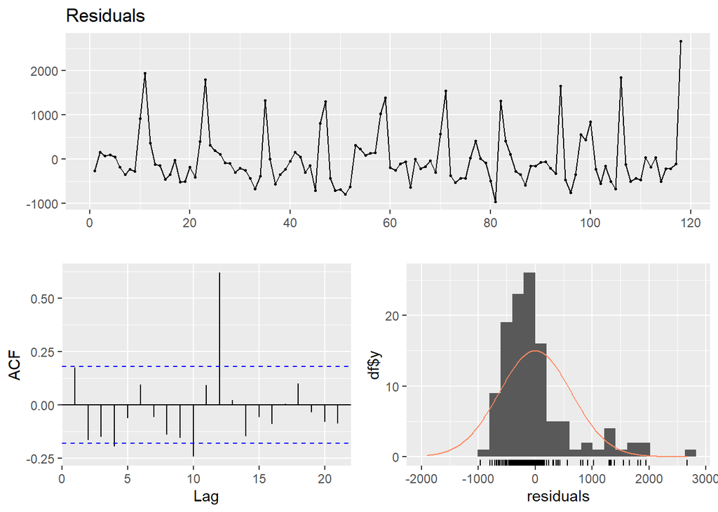

```
##
##  Ljung-Box test
##
## data:  Residuals
## Q* = 29.73, df = 10, p-value = 0.0009481
##
## Model df: 0.   Total lags used: 10
```

```r
checkresiduals(lm_base2$residuals)
```

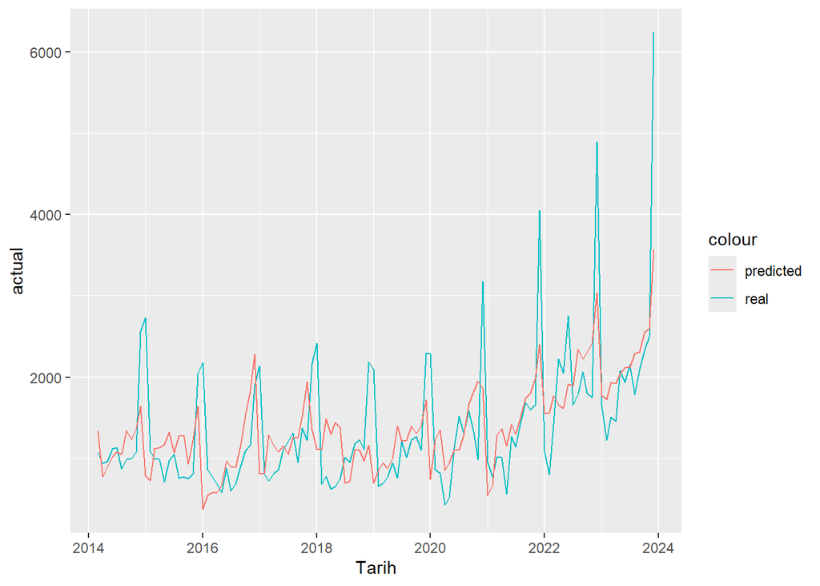

```r
tmp2=copy(data)
tmp2[,actual:=toplam_kapanan_isyeri]
tmp2[,predicted_trend_finans_güven_endeksi_toplam_ofis_yıl:=predict(lm_base2,tmp)]
tmp2[,residual_trend_finans_güven_endeksi_toplam_ofis_yıl:=actual-predicted_trend_finans_güven_endeksi_toplam_ofis_yıl]
#head(tmp)
ggplot(tmp2 ,aes(x=Tarih)) +
        geom_line(aes(y=actual,color='real')) +
        geom_line(aes(y=predicted_trend_finans_güven_endeksi_toplam_ofis_yıl,color='predicted'))
```

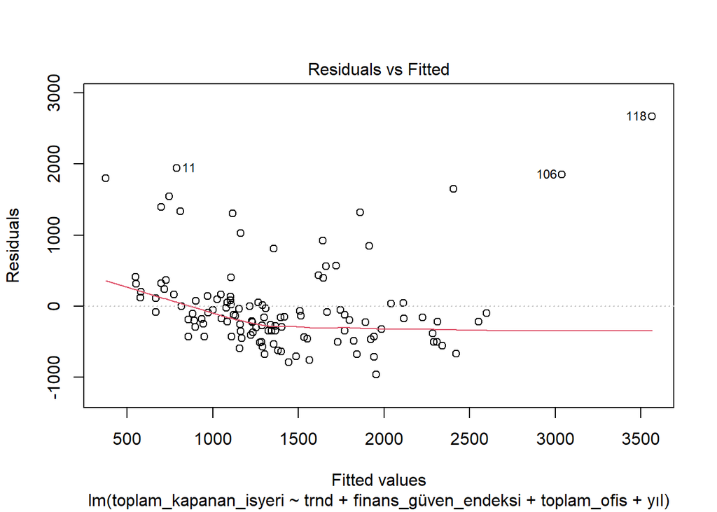

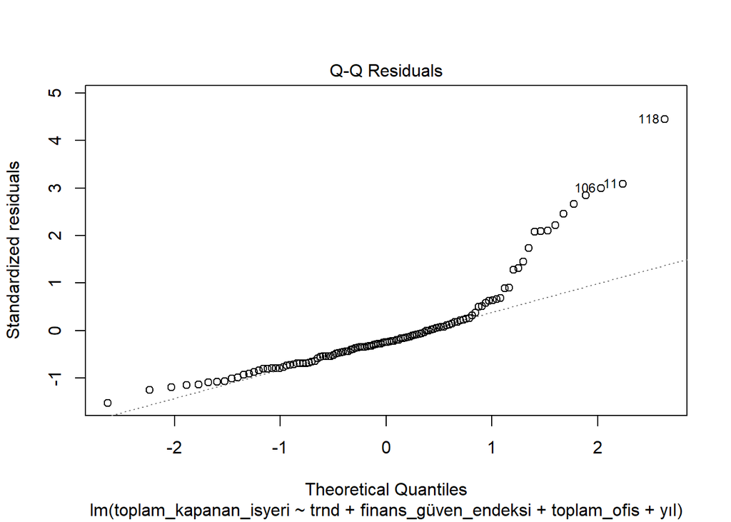

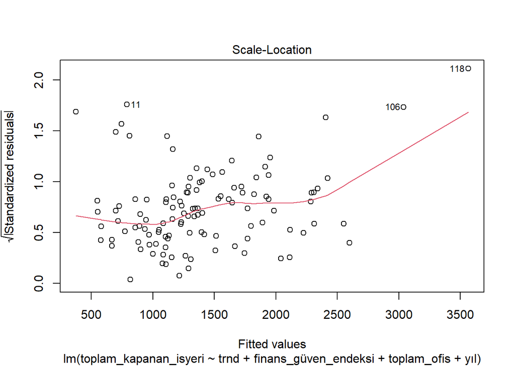

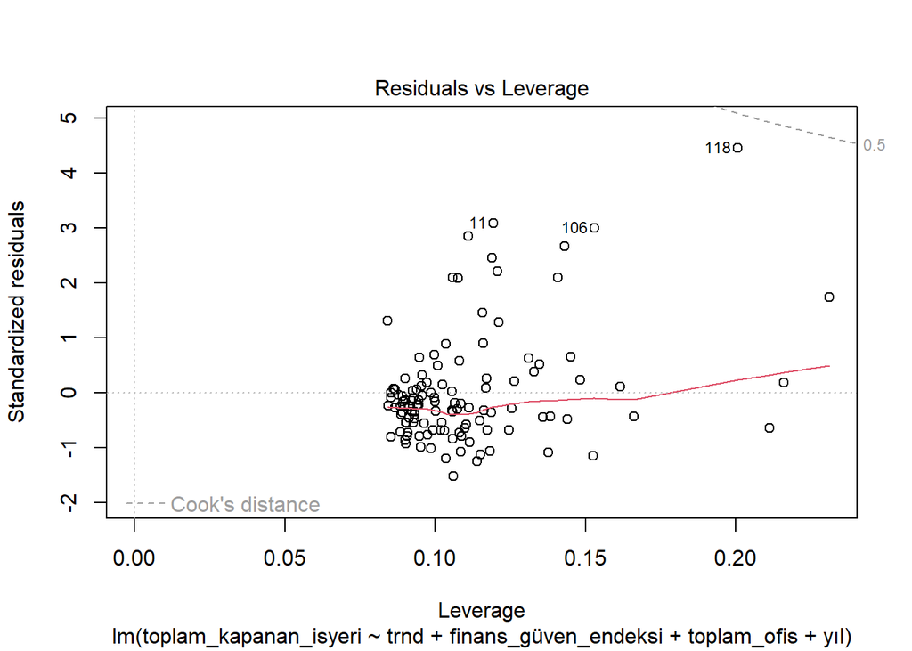

```r
plot(lm_base2)
```